# preprocess nanoString data

import and normalize data

Amrit Singh

December 12th, 2016

# 1 Purpose of this analysis:

```r
## input:
## output:
## aya43@sfu.ca
## created 20170807
## last modified 20180614

## root directory
root = "~/projects/asthma"
# setwd(root)
result_dir = paste0(root, "/result"); dir.create(result_dir, showWarnings=F)


## input directory
data_dir = paste0(root, "/data/RNApancancer")

library(devtools); #install_github("singha53/amritr")
library(amritr);
library(dplyr);
library(tidyr);
library(psych); # geometric.mean()
library(affy); #mv.pairs()
library(ggbiplot); #ggbiplot() #devtools::install_github("vqv/ggbiplot")
library(NormqPCR) # geNorm
library(GGally) # ggpairs()
library(limma) # lmFit, eBayes
```

# 2 1) import nanoString data

```r
filePaths <- c(paste0(data_dir, "/data/rawdata/nanoString/20150703_asingh - pancancer MAXset A_RCC"),
    paste0(data_dir, "/data/rawdata/nanoString/20150709_setB max fov - ykw n amrit_RCC"),
    paste0(data_dir, "/data/rawdata/nanoString/20150709_Set3-C-AMRIT-KYW-MAX_RCC"))

#----------------------------------------------
# import RC files and compile into a dataframe
#----------------------------------------------
setName <- paste("Set", 1:length(filePaths))
date <- c("2015-07-03", "2015-07-03", "2015-07-03")
DatList <- list()
for (h in 1:length(filePaths)) {
    files <- list.files(filePaths[h], full.names = TRUE)
    dat <- lapply(as.list(files), function(i) {
        rccToDat(fileName = i)
    }) %>% do.call(rbind, .)
    dat$Set <- setName[h]
    dat$Date <- date[h]
    DatList[[h]] <- dat
}
Dat <- do.call(rbind, DatList)
## Fix gene Names for some genes
Dat$Name[Dat$Accession == "NM_014512.1"] <- "KIR2DS1"  ## KIR_Activating_Subgroup_2
Dat$Name[Dat$Accession == "NM_014218.2"] <- "KIR2DL1"  ## KIR_Inhibiting_Subgroup_1
Dat$Name[Dat$Accession == "NM_001083539.1"] <- "KIR3DS1"  ## KIR_Activating_Subgroup_1
Dat$Name[Dat$Accession == "NM_014511.3"] <- "KIR2DL3"  ## KIR_Inhibiting_Subgroup_2
Dat$Name[Dat$Name == "IL8"] <- "CXCL8"
write.csv(Dat, paste0(data_dir, "/data/preprocessedData/cleanedRawData_panCancerDiscovery.csv"))

#------------
# import data
#------------
sampleMap <- c(paste0("E", 1:36))
data <- read.csv(paste0(data_dir, "/data/preprocessedData/cleanedRawData_panCancerDiscovery.csv"),
    row.names = 1)
names(sampleMap) <- unique(data$fileName)
data$Sample <- sampleMap[as.character(data$fileName)]
write.csv(data, paste0(data_dir, "/data/preprocessedData/cleanedRawData_panCancerDiscovery.csv"))


## Demographics
demo <- readRDS(paste0(root, "/data/RNAseq/demo/allsitesDemo.rds"))
rownames(demo) <- paste(demo$concealedID, demo$Time, sep = "_")
demoPre0 <- demo[!is.na(demo$EorV_number), ]
rownames(demoPre0) <- demoPre0$EorV_number
dim(demoPre0)
```

```
## [1] 111  65
```

```r
demoPre <- demoPre0[sampleMap, ]
```

# 3 2) Quality Control / Quality Assessment

## 3.1 2a. Fields of View (FOV)

- each lane is imaged in discrete units called FOVs
- FOV Count = # of FOVs for which imaging was attempted
- FOV Counted = # of FOVs sucessfully imaged
- Causes of discrepancy between FOV Count & FOV Counted: optical issues such as bubbles or insufficient oiling of cartridge
- *Imaging QC (nSolver default)*: Flag lanes when percent FOV registration is less than 75

## 3.2 2b. Binding Density

```r
qc <- data %>% mutate(FOVratio = FovCounted_Lane_Attributes/FovCount_Lane_Attributes) %>%
    dplyr::select(FOVratio, BindingDensity = BindingDensity_Lane_Attributes,
        Sample, Set, ID_Lane_Attributes) %>% gather(QCVar, QCmetrics, -c(Sample,
    Set, ID_Lane_Attributes)) %>% group_by(Sample, QCVar, Set) %>% # distinct(Sample, Set, ID_Lane_Attributes) %>%
mutate(Sample_Lane = paste(Sample, ID_Lane_Attributes, sep = "_"))
qc$Sample_Lane <- factor(qc$Sample_Lane, levels = unique(qc$Sample_Lane))

qc %>% ungroup %>% dplyr::group_by(QCVar) %>% dplyr::summarise(min = min(QCmetrics),
    max = max(QCmetrics))
```

```
## # A tibble: 2 x 3
##   QCVar            min   max
##   <chr>          <dbl> <dbl>
## 1 BindingDensity 0.41  1.17
## 2 FOVratio       0.941 0.989
```

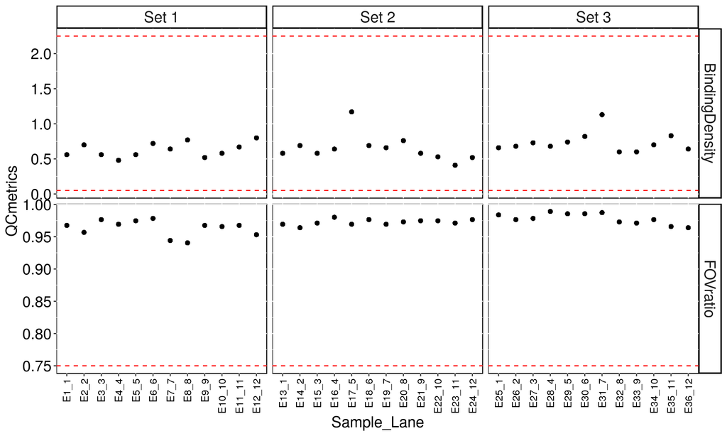

FOV ratio and Binding density.

```r
hline.data <- data.frame(yint = c(0.75, 0.05, 2.25), QCVar = c("FOVratio", rep("BindingDensity",
    2)))
ggplot(data = qc, aes(x = Sample_Lane, y = QCmetrics)) + geom_point() + facet_grid(QCVar ~
    Set, scale = "free") + geom_hline(data = hline.data, aes(yintercept = yint),
    lty = 2, col = "red") + customTheme(sizeStripFont = 15, xAngle = 90, hjust = 1,
    vjust = 0.5, xSize = 10, ySize = 15, xAxisSize = 15, yAxisSize = 15)
```

> all samples pass Imaging QC and Binding Density QC.

## 3.3 2c. Internal Controls

- nanoString uses External RNA Control Consortium (ERCC) controls for both positive and negative controls
- ERRC is a group that develops RNA transcripts not homologous to known organisms, generate consistent results in gene expression data –> used to assess technical performance in gene expression assays.

### 3.3.1 2d. Positive Controls

- For each sample, there are six positive controls (POS_A-POS_F) corresponding to six different concentrations in the 30 ul hybridzation: 128fM, 32fM, 8fM, 2fM, 0.5fM, and 0.125fM.
- *Positive Control Linearity QC*: Flag lanes when Positive Control $R^2$ value is less than 0.9

```r
posConc <- c(128, 32, 8, 2, 0.5, 0.125)
names(posConc) <- paste0(paste("POS", LETTERS[1:6], sep = "_"), paste0("(",
    posConc, ")"))
posDat <- data %>% filter(CodeClass == "Positive_Code_Summary") %>% mutate(posConc = posConc[as.character(Name)],
    Sample_Lane = paste(Sample, ID_Lane_Attributes, sep = "_"))

mods <- posDat %>% group_by(ID_Lane_Attributes, Set) %>% do(., r2 = summary(lm(Count ~
    posConc, data = .))$r.squared)
r.squared <- data.frame(ID_Lane_Attributes = mods$ID_Lane_Attributes, R2 = round(unlist(mods$r2),
    2), Set = mods$Set)
r.squared$x <- 20
r.squared$y <- 100

all(mods$r2 > 0.99)
```

```
## [1] TRUE
```

```r
## order E samples from 1-36
posDat$Sample_Lane <- factor(posDat$Sample_Lane, levels = unique(posDat$Sample_Lane))

# ggplot(posDat, aes(x = posConc, y = Count)) + geom_point() +
# facet_grid(Set~ID_Lane_Attributes) + scale_x_log10() + scale_y_log10() +
# stat_smooth(method = 'lm') + geom_text(aes(x, y, label = paste0('R^2 ==',
# R2), size = 1), data = r.squared, parse = TRUE) + theme(legend.position =
# 'none') + xlab('Concentration (fM)') + ggtitle('Positive Controls') +
# customTheme(sizeStripFont=10, xAngle=0, hjust=0.5, vjust=1, xSize=10,
# ySize=10, xAxisSize=10, yAxisSize=10)
```

> all samples pass Positive Control Linearity: range = QC 0.9901702, 0.99516

### 3.3.2 2e. Negative Controls

- estimate systemic background counts within any single hybridization reaction.
- *Positive Control Limit of Detection QC*: Flag lanes when 0.5fM positive control is less than or equal to 2 standard deviations above the mean of the negative controls.

```r
negSD <- data %>% dplyr::filter(CodeClass == "Negative_Code_Summary") %>% group_by(fileName,
    Set, Sample) %>% dplyr::summarise(negThres = mean(Count) + 2 * sd(Count))
pos0.5 = posDat %>% filter(posConc == 0.5)
all(levels(negSD$Sample) == levels(pos0.5$Sample))  # TRUE
```

```
## [1] TRUE
```

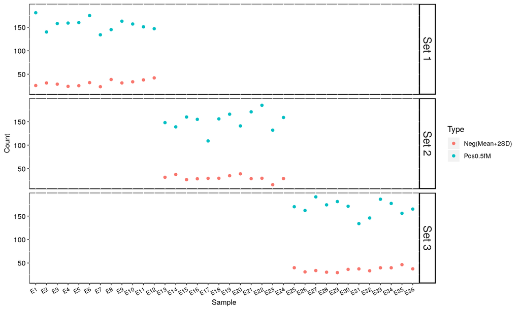

Positive Control Limit of Detection QC.

```r
negPos <- as.data.frame(rbind(negSD[, c("Sample", "Set", "negThres")], setNames(pos0.5[,
    c("Sample", "Set", "Count")], c("Sample", "Set", "negThres"))))
negPos$Type = rep(c("Neg(Mean+2SD)", "Pos0.5fM"), each = nrow(negSD))
negPos$Sample <- factor(negPos$Sample, levels = unique(negPos$Sample)[order(as.numeric(gsub("E",
    "", unique(negPos$Sample))))])

ggplot(negPos, aes(x = Sample, y = negThres, color = Type)) + geom_point() +
    ylab("Count") + customTheme(sizeStripFont = 15, xAngle = 30, hjust = 1,
    vjust = 1, xSize = 8, ySize = 10, xAxisSize = 10, yAxisSize = 10) + facet_grid(Set ~
    .)
```

> all samples are pass the Positive control limit of detection QC

# 4 3) Normalization

## 4.1 3a. Positive Control Normalization

- Positive controls normalize all platform associated sources of variation (e.g. automated purfication, hybridization conditions etc.)
- does not account for sample input between technical and biological replicates
- Positive Control Scaling factor QC: If the positive control scaling factor is outside a range of 0.3-3, –> may indicate significant under-performance of a lane

```r
# str(posDat)

posNF <- posDat %>% group_by(Sample) %>% dplyr::summarise(posGeoMean = geometric.mean(Count),
    fileName = unique(fileName)) %>% mutate(posNF = mean(posGeoMean)/posGeoMean)
range(posNF$posNF)
```

```
## [1] 0.8437908 1.2326545
```

```r
all(posNF$posNF < 3 & posNF$posNF > 0.3)
```

```
## [1] TRUE
```

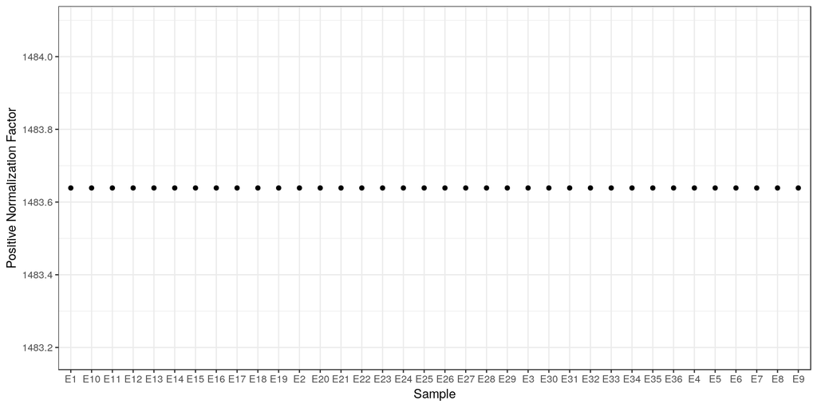

```r
dataNorm <- full_join(data, posNF, by = "fileName") %>% mutate(posNorm = Count *
    posNF)

# check if the sum of the positive controls is the same for each assay
dataNorm %>% group_by(fileName) %>% filter(CodeClass == "Positive_Code_Summary") %>%
    dplyr::summarise(sumPosSample = geometric.mean(posNorm), Sample = unique(Sample.x),
        Set = unique(Set)) %>% dplyr::select(Sample, sumPosSample) %>% ggplot(aes(x = Sample,
    y = sumPosSample)) + geom_point() + theme_bw() + ylab("Positive Normalization Factor")
```

## 4.2 3b. Correlation between replicates using endogenous genes only

```r
all(dataNorm$Sample.x == dataNorm$Sample.y)
```

```
## [1] TRUE
```

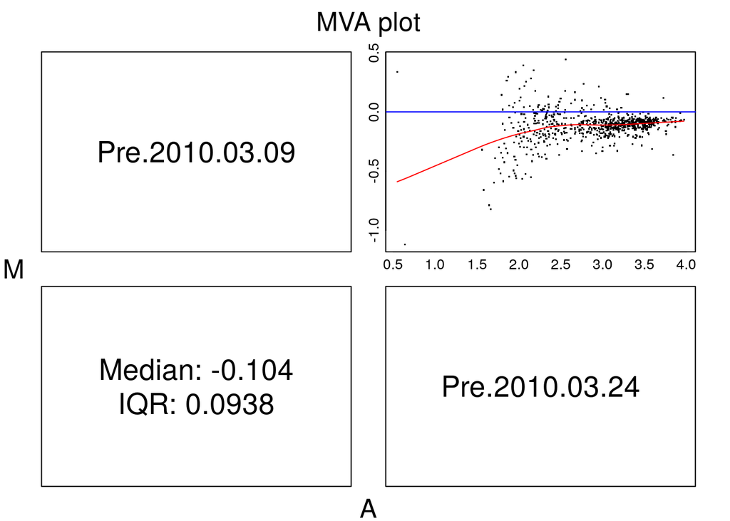

```r
expDat0 <- dataNorm %>% filter(CodeClass == "Endogenous_Code_Summary") %>% dplyr::select(Name,
    posNorm, Sample.x) %>% tidyr::spread(Name, posNorm)
expDat <- expDat0[, -1]
rownames(expDat) <- expDat0$Sample.x

## LST_026
samples <- as.character(demoPre$NAME)[rownames(demoPre) %in% rownames(expDat)]
names(samples) <- as.character(rownames(demoPre)[rownames(demoPre) %in% rownames(expDat)])
Y <- as.data.frame(log2(t(expDat[names(samples[samples == "L_ST_026"]), ])))
colnames(Y) <- rownames(demo)[as.character(demo$EorV_number) %in% colnames(Y)]
colnames(Y) <- paste(colnames(Y), as.character(demo[colnames(Y), "AIC_YMD"]),
    sep = ".")
colnames(Y) <- gsub("-", ".", unlist(lapply(strsplit(colnames(Y), "_"), function(i) i[2])))

## from affy
mva.pairs(Y)
```

```r
reps <- normalize.loess(Y)
```

```
## Done with 1 vs 2 in iteration 1
## 1 0.003830754
```

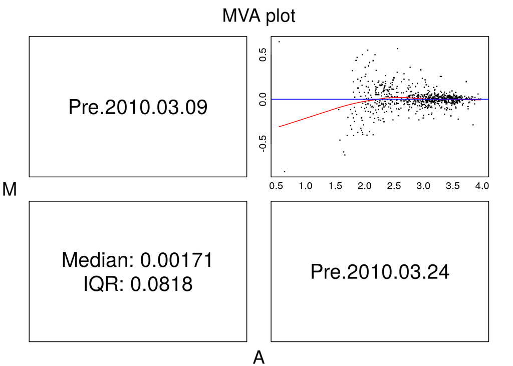

```r
mva.pairs(reps)
```

```r
pdf(paste0(data_dir, "/results/Figures/Fig.S1.pdf"), height = 8, width = 8)
ggpairs(Y, mapping = aes(colors = "black", alpha = 0.5), title = "LST026", lower = list(continuous = "smooth",
    combo = "facetdensity", mapping = aes(color = "blue")))
dev.off()
```

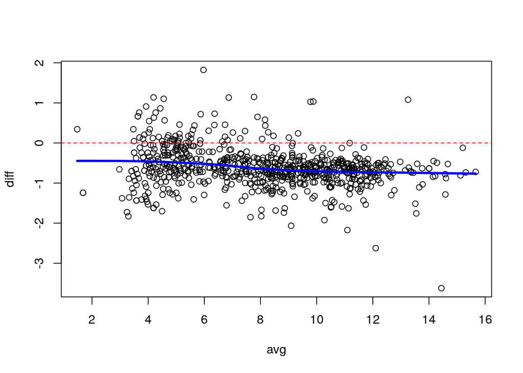

```r
## MA plot
diff <- Y[, "Pre.2010.03.09"] - Y[, "Pre.2010.03.24"]
avg <- (Y[, "Pre.2010.03.09"] + Y[, "Pre.2010.03.24"])/2

plot(diff ~ avg)
lines(lowess(diff ~ avg), col = "blue", lwd = 3)
abline(h = 0, lty = 2, col = "red")
```

## 4.3 3c. Principal Component Analysis using endogenous genes only LST26 (14, 17)

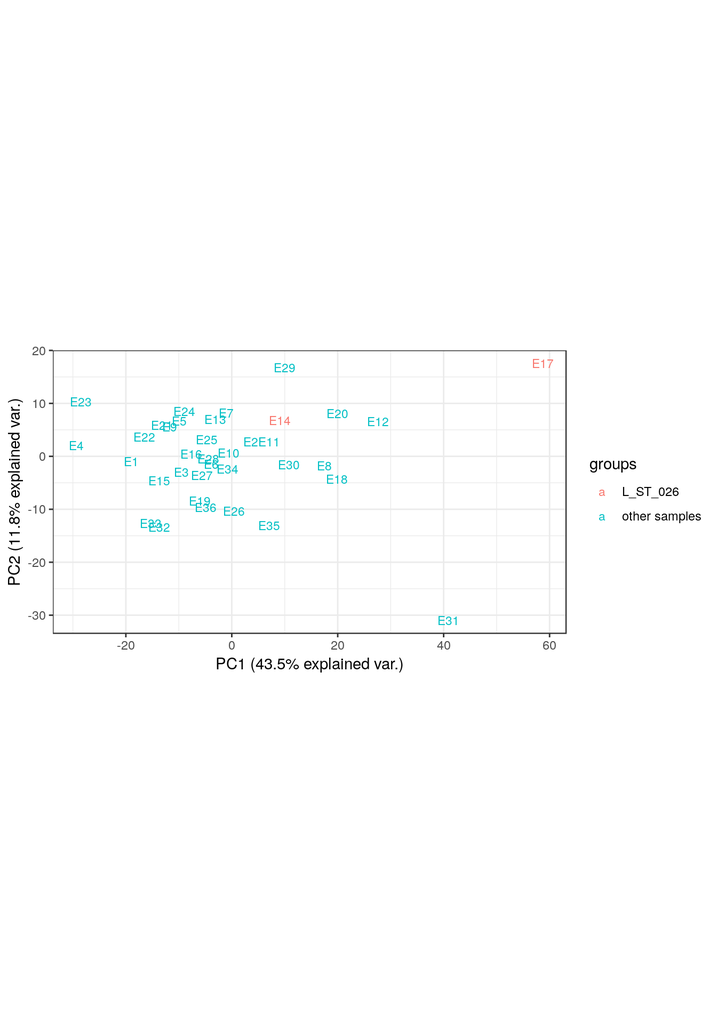

```r
group <- samples[rownames(expDat)]
group[group != "L_ST_026"] <- "other samples"

pcaDat <- prcomp(expDat, scale. = TRUE)
## color replicates
ggbiplot(pcaDat, obs.scale = 1, var.scale = 1, group = group, ellipse = F, circle = F,
    var.axes = FALSE, labels = rownames(expDat)) + theme_bw()
```

## 4.4 3d. Filtering of low abundant features

```r
## remove the second replicate (L_ST_026_R1)
as.character(demoPre$UniqueID)[rownames(demoPre) %in% "E17"]
```

```
## [1] "L_ST_026_R1"
```

```r
dataNorm2 <- dataNorm %>% filter(Sample.x != "E17")

allCounts0 <- dataNorm2 %>% filter(CodeClass == "Endogenous_Code_Summary") %>%
    dplyr::select(Sample.x, Name, posNorm) %>% spread(Name, posNorm)
allCounts <- as.matrix(allCounts0[, -1])
rownames(allCounts) <- allCounts0$Sample

## 1) determine max of negative controls
maxNegativeCount <- dataNorm2 %>% filter(CodeClass == "Negative_Code_Summary") %>%
    dplyr::summarize(maxNeg = max(posNorm))
maxNegativeCount
```

```
##     maxNeg
## 1 45.91899
```

```r
passThreshold <- colSums(allCounts > maxNegativeCount$maxNeg)/nrow(allCounts)
sum(passThreshold > 0)  ## keep genes with at least 1 count of 35 samples > than the max value of negative controls
```

```
## [1] 600
```

```r
## 2) filter genes with all counts below the maximum value of the negative
## counts
dataNormEndoFiltered <- dataNorm2 %>% filter(Name %in% names(passThreshold)[passThreshold >
    0]) %>% mutate(Name = as.character(Name))
dataNormHk <- filter(dataNorm2, CodeClass %in% "Housekeeping_Code_Summary")
dataNorm3 <- rbind(as.data.frame(dataNormEndoFiltered), as.data.frame(dataNormHk))
```

## 4.5 3e. House-keeping normalization

[figure not shown]

```r
hk <- filter(dataNorm3, CodeClass == "Housekeeping_Code_Summary")

## Plot house-keeping genes for 35 samples
ggplot(hk, aes(x = as.numeric(Sample.x), y = posNorm, color = Name)) + geom_point() +
    geom_line() + scale_y_log10() + customTheme(sizeStripFont = 15, xAngle = 0,
    hjust = 0.5, vjust = 0.5, xSize = 10, ySize = 15, xAxisSize = 15, yAxisSize = 15) +
    xlab("35 samples") + ylab("Counts")
```

```r
hkDat0 <- hk %>% dplyr::select(Sample.x, Name, posNorm) %>% spread(Sample.x,
    posNorm)
hkDat <- as.matrix(hkDat0[, -c(1)])
# hkDat[hkDat < 1] <- 1
hkDat <- log2(hkDat)
rownames(hkDat) <- as.character(hkDat0$Name)

## Use geNorm to select house-keepers
res.BM <- selectHKs(t(hkDat), method = "geNorm", Symbols = rownames(hkDat),
    minNrHK = 2, log = FALSE)
```

[output not shown]

[output cut: 251 more lines]

```
## 0.02695233 0.02788983
##        TBP      MRPS5     EIF2B4       EDC3       FCF1      ABCF1
## 0.02144592 0.02252122 0.02402629 0.02409967 0.02418918 0.02564835
##      ERCC3
## 0.02668997
##        TBP      MRPS5       EDC3     EIF2B4       FCF1      ABCF1
## 0.02109066 0.02182331 0.02316369 0.02328190 0.02381394 0.02511528
##        TBP      MRPS5       FCF1     EIF2B4       EDC3
## 0.02061275 0.02080351 0.02247625 0.02295427 0.02322599
##        TBP      MRPS5       FCF1     EIF2B4
## 0.02027623 0.02038751 0.02143747 0.02272651
##        TBP       FCF1      MRPS5
## 0.01891102 0.01966644 0.02048458
##       FCF1        TBP
## 0.01809288 0.01809288
```

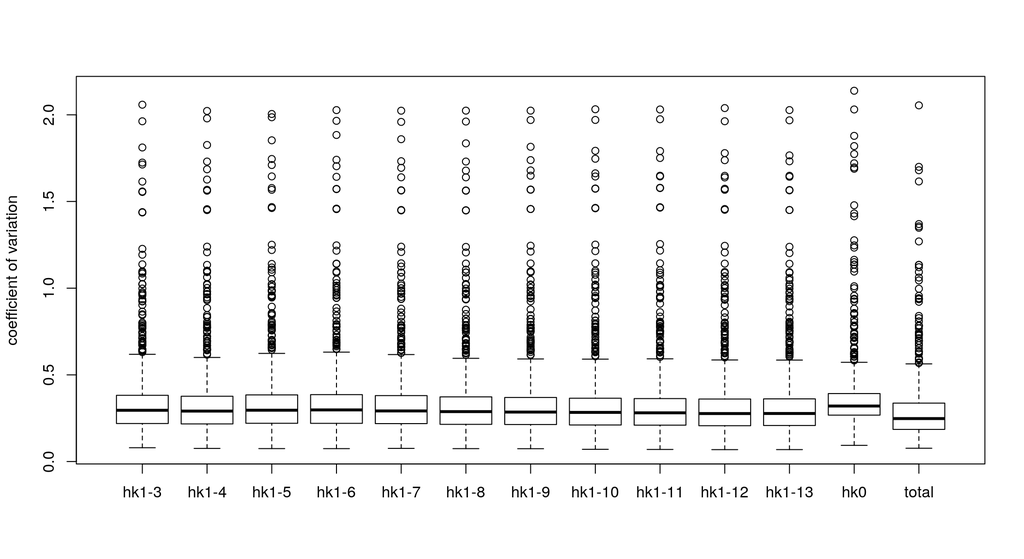

```r
cvList <- list()
for (i in 3:13) {
    genes <- as.character(res.BM$ranking[1:i])

    ## House-keeping normalization factor
    hkNF <- dataNorm3 %>% filter(Name %in% genes) %>% group_by(Sample.x) %>%
        dplyr::summarise(hkGeoMean = geometric.mean(posNorm)) %>% mutate(hkNF = mean(hkGeoMean)/hkGeoMean)

    ## normalize data
    hkNorm <- full_join(dataNorm3, hkNF, by = "Sample.x") %>% mutate(hkNorm = posNorm *
        hkNF)

    ## calculate CVs
    cvDat <- hkNorm %>% filter(CodeClass == "Endogenous_Code_Summary") %>% group_by(Name) %>%
        dplyr::summarise(cv = sd(hkNorm)/mean(hkNorm))
    cv <- cvDat$cv
    names(cv) <- cvDat$Name
    cvList[[i - 2]] <- cv
}
names(cvList) <- paste0("hk", "1-", 3:13)

## cvs of raw data calculate CVs
cvDat <- dataNorm3 %>% filter(CodeClass == "Endogenous_Code_Summary") %>% group_by(Name) %>%
    dplyr::summarise(cv = sd(posNorm)/mean(posNorm))
cv <- cvDat$cv
names(cv) <- cvDat$Name
cvList$hk0 <- cv

## total sum normalization total sum normalization factor
totalNF <- dataNormEndoFiltered %>% group_by(Sample.x) %>% dplyr::summarise(totalsumMean = sum(posNorm)) %>%
    mutate(totalsumNF = mean(totalsumMean)/totalsumMean)
## normalize data
totalNorm <- full_join(dataNormEndoFiltered, totalNF, by = "Sample.x") %>% mutate(totalNorm = posNorm *
    totalsumNF)

# ## ttm normalization mdge = DGEList(counts=m1, group=group) # ttm
# normalization m2 = calcNormFactors(mdge)


## calculate CVs
cvDat <- totalNorm %>% filter(CodeClass == "Endogenous_Code_Summary") %>% group_by(Name) %>%
    dplyr::summarise(cv = sd(totalNorm)/mean(totalNorm))
cv <- cvDat$cv
names(cv) <- cvDat$Name
cvList$total <- cv

## boxplot of CVs for various normalizations
boxplot(do.call(cbind, cvList), ylab = "coefficient of variation")
```

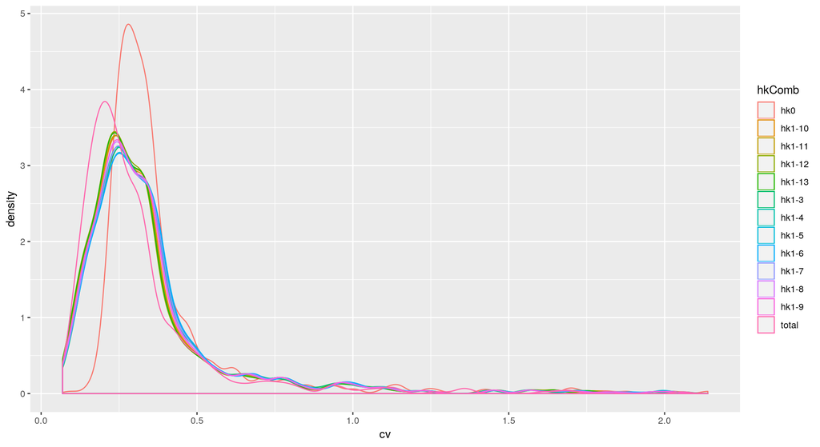

```r
## histogram of CVs for various normalizations
do.call(cbind, cvList) %>% as.data.frame %>% gather(hkComb, cv) %>% ggplot(aes(x = cv,
    color = hkComb)) + geom_density(alpha = 0.5)
```

# 5 4) Differential Expression Analysis: ERvsDR after total sum normalization (since this normalized had the lowest mean cv compared to the hk normalizations

```r
genEset0 <- totalNorm %>% filter(CodeClass == "Endogenous_Code_Summary") %>%
    dplyr::select(Sample.x, Name, totalNorm) %>% spread(Sample.x, totalNorm)
genEset <- log2(as.matrix(genEset0[, -1]))
genEset[genEset < 0] <- 0
rownames(genEset) <- genEset0$Name

demoPre <- demoPre[colnames(genEset), ]
all(demoPre$EorV_number == colnames(genEset))
```

```
## [1] TRUE
```

```r
table(demoPre$calculated_Response, demoPre$givenResponse)
```

```
##
##      DR ER
##   DR 20  0
##   ER  0 15
```

```r
## differential expression analysis
design <- model.matrix(~factor(demoPre$calculated_Response, levels = c("ER",
    "DR")))
fit <- eBayes(lmFit(genEset, design, method = "ls"))
top.total <- topTable(fit, coef = 2, adjust.method = "BH", n = nrow(fit))
length(top.total$logFC[top.total$P.Value < 0.05])
```

```
## [1] 50
```

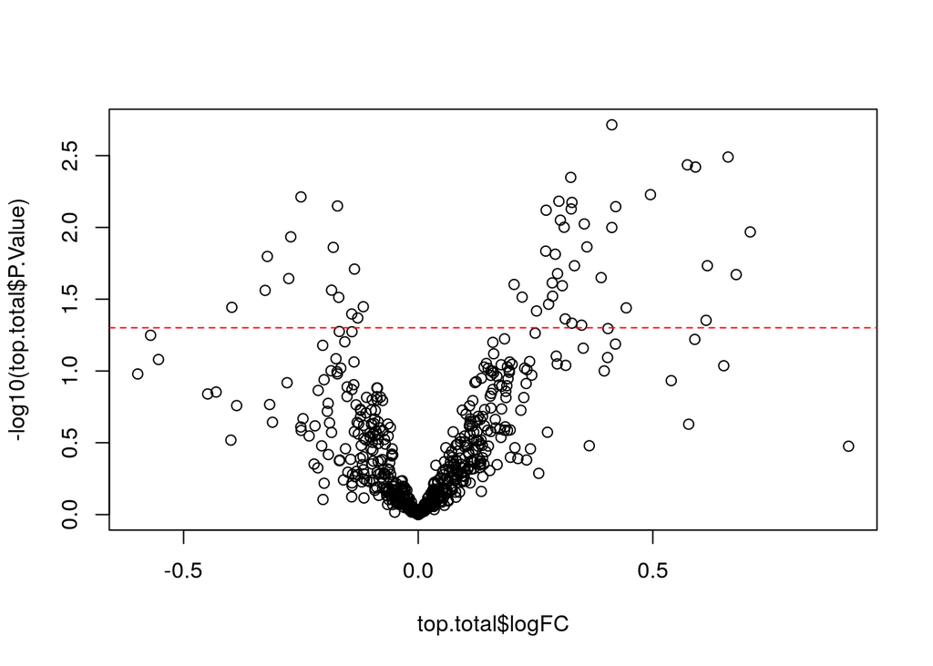

```r
plot(-log10(top.total$P.Value) ~ top.total$logFC)
abline(h = -log10(0.05), lty = 2, col = 2)
```

# 6 5) Gene Annotation

```r
ann0 <- read.csv(paste0(root, "/data/Cells_nCounter_Human_PanCancer_Immune_Profiling_Panel_Gene_List.csv"),
    row.names = 1)
table(ann0$Gene.Class)
```

```
##
##                                        CT Antigen
##                                                30
##                                                HK
##                                                40
##                                   Immune Response
##                                               582
##              Immune Response - Cell Type specific
##                                               105
## Immune Response - Cell Type specific / Checkpoint
##                                                 4
##                      Immune Response - Checkpoint
##                                                 9
```

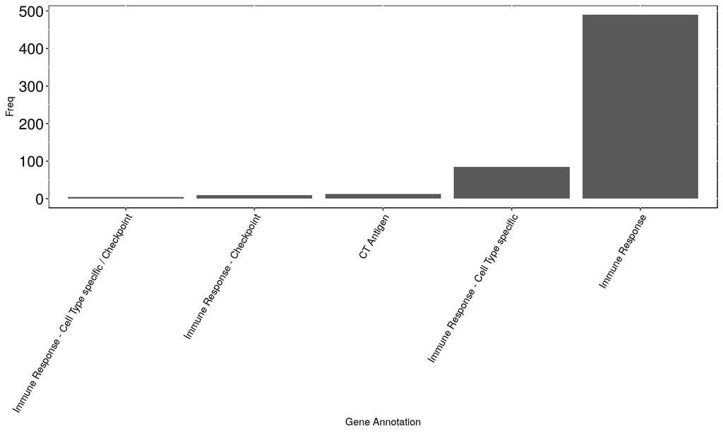

Gene Annotations

```r
ann <- ann0[rownames(genEset), ]

## plot total number of genes
table(as.character(ann$Gene.Class))[order(table(as.character(ann$Gene.Class)))] %>%
    as.data.frame %>% ggplot(aes(x = Var1, y = Freq)) + geom_bar(stat = "identity") +
    customTheme(sizeStripFont = 10, xAngle = 60, hjust = 1, vjust = 1, xSize = 10,
        ySize = 15, xAxisSize = 10, yAxisSize = 10) + xlab("Gene Annotation")
```

```r
annCellType <- subset(ann, Gene.Class == "Immune Response - Cell Type specific")
```

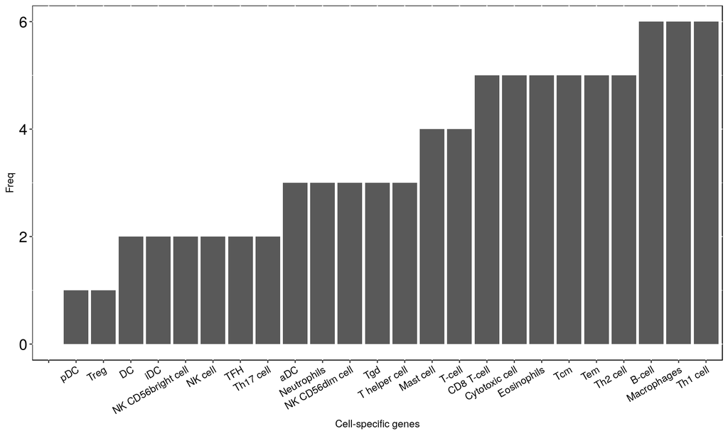

Cell-specific genes

```r
## plot break-down of cell-specific genes
table(annCellType$Cell.Type)[order(table(annCellType$Cell.Type))] %>% as.data.frame %>%
    ggplot(aes(x = Var1, y = Freq)) + geom_bar(stat = "identity") + customTheme(sizeStripFont = 10,
    xAngle = 30, hjust = 1, vjust = 1, xSize = 10, ySize = 15, xAxisSize = 10,
    yAxisSize = 10) + xlab("Cell-specific genes")
```

```r
annCT <- subset(ann, Gene.Class == "CT Antigen")
annImmRes <- subset(ann, !(Gene.Class %in% c("Immune Response - Cell Type specific",
    "CT Antigen", "HK")))

## gene set of annotations
imm <- strsplit(gsub(", ", ",", as.character(ann$Annotation)), ",")
names(imm) <- rownames(ann)
dfAnn <- data.frame(GeneName = rep(names(imm), unlist(lapply(imm, length))),
    Pathway = unlist(imm))

## gene set of immune responses
immRes <- strsplit(gsub(", ", ",", as.character(annImmRes$Annotation)), ",")
names(immRes) <- rownames(annImmRes)
dfImmRes <- data.frame(GeneName = rep(names(immRes), unlist(lapply(immRes, length))),
    Pathway = unlist(immRes))
dim(dfAnn)
```

```
## [1] 1254    2
```

```r
dim(dfImmRes)
```

```
## [1] 978   2
```

# 7 write out datasets

```r
save(demoPre = demoPre, genEset = genEset, ann = ann, dfAnn = dfAnn, dfImmRes = dfImmRes,
    file = paste0(data_dir, "/data/preprocessedData/panCancerDatasets.RDATA"))
```

```r
file.edit(tufte:::template_resources("tufte_html", "..", "skeleton", "skeleton.Rmd"))

# create a bib file for the R packages used in this document
knitr::write_bib(c("base", "rmarkdown"), file = "skeleton.bib")
```

[^1]: [nCounter Expression Data Analysis Guide](http://www.nanostring.com/media/pdf/MAN_nCounter_Gene_Expression_Data_Analysis_Guidelines.pdf)